# Model Selection

In this notebook, we will compare the results obtained from the different models previously calculated and choose the best one for the optimization.

The metric used for this study will be the roc curve, the F1 score, Recall, precssion, the confussion matrix and the F2 Score. As false negatives may be counterproductive for the company, we will give more importance to the results obtained with the F2 Score.

We will start with the calculation of the metrics, and afterwards the results will be compared and commented.

# Library

```python
import pandas as pd
import pickle
from sklearn.model_selection import train_test_split
import numpy as np

import seaborn as sns
import matplotlib.pyplot as plt
import matplotlib

from sklearn import metrics
from sklearn import model_selection
from sklearn.model_selection import train_test_split
from sklearn.metrics import classification_report, confusion_matrix, roc_curve, auc, \
                            silhouette_score, recall_score, precision_score, make_scorer, \
                            roc_auc_score, f1_score, precision_recall_curve, fbeta_score, \
                            accuracy_score, ConfusionMatrixDisplay

import pickle
import re
import warnings
warnings.filterwarnings('ignore')

import functions as fx
```

# Loading data

```python
#Read the traing data
pd_fraud = pd.read_parquet('../data/training_data.parquet')

#Separate the training data in training and validation
X_train, X_validation, y_train, y_validation = train_test_split(pd_fraud, pd_fraud['isFraud'],
                                                                test_size=0.15,
                                                                random_state=1)

X_train = X_train.drop(['isFraud'], axis=1)
X_validation = X_validation.drop(['isFraud'], axis=1)
```

```python
# Load model data
base = fx.load_model("../models/base.pickle")
svm = fx.load_model("../models/model_svm.pickle")
lasso = fx.load_model("../models/model_lasso.pickle")
random_forest = fx.load_model("../models/random_forest.pickle")
xgboost = fx.load_model("../models/XGBoost.pickle")
lightgbm = fx.load_model("../models/LightGBM.pickle")
adaboost = fx.load_model("../models/AdaBoost.pickle")
```

## Base model

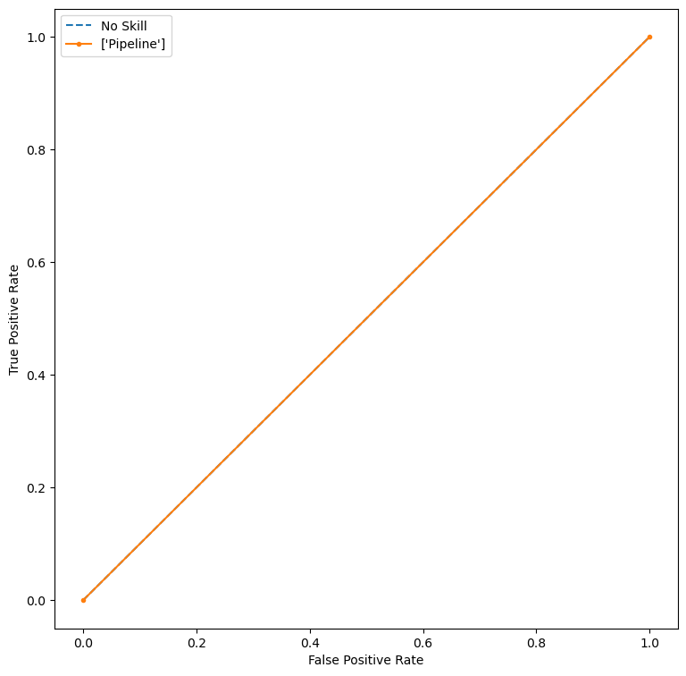

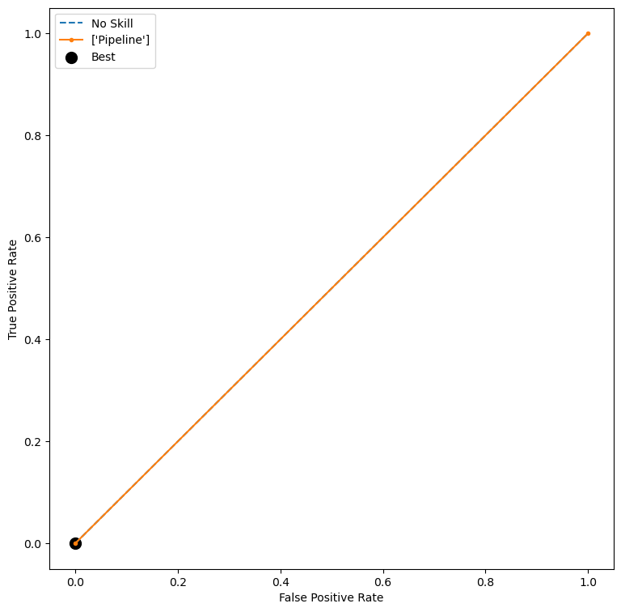

```
ROC-AUC score of the model: 0.5
Accuracy of the model: 0.9987522749127784

Classification report:
              precision    recall  f1-score   support

           0       1.00      1.00      1.00    125672
           1       0.00      0.00      0.00       157

    accuracy                           1.00    125829
   macro avg       0.50      0.50      0.50    125829
weighted avg       1.00      1.00      1.00    125829


Confusion matrix:
[[125672      0]
 [   157      0]]

F2 Score:
0.4998751028214034
```

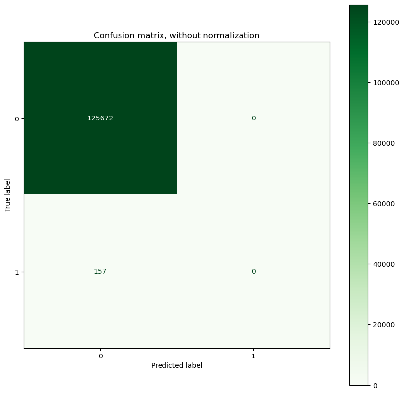

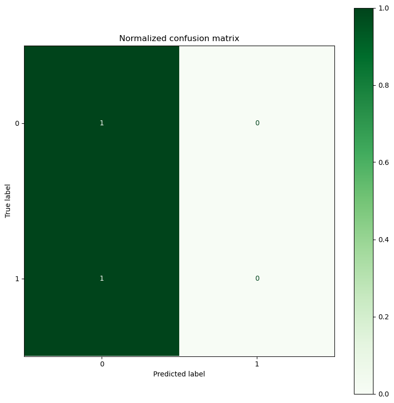

```python
fx.model_analysis(base, X_validation, y_validation)
```

## Lasso

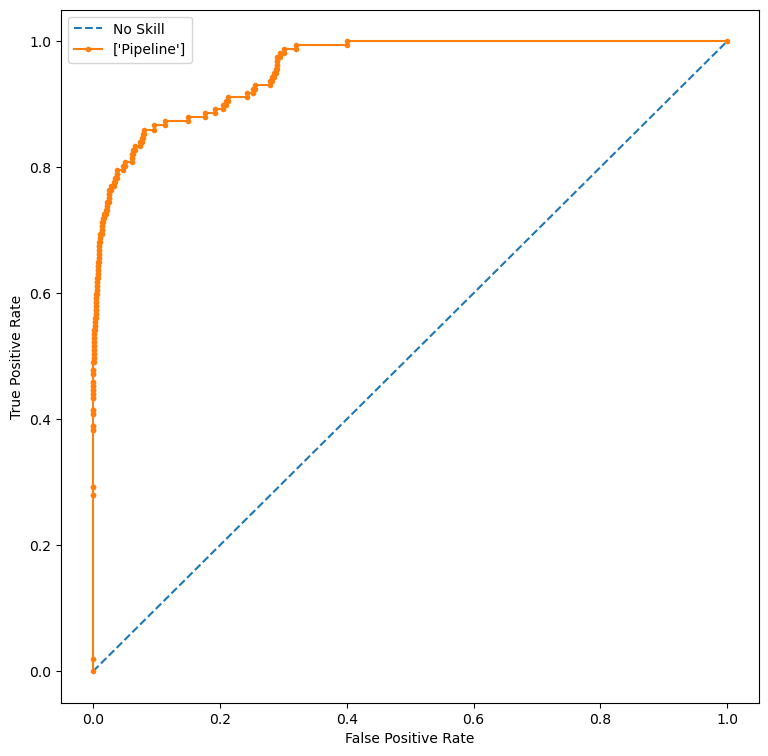

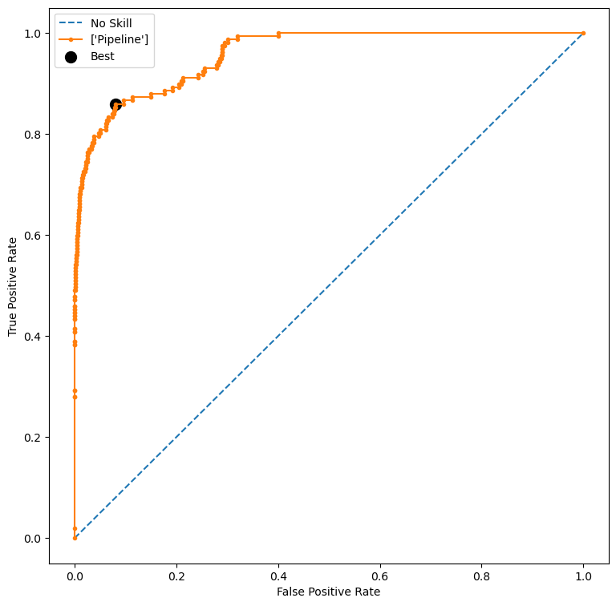

```
ROC-AUC score of the model: 0.9577539428288299
Accuracy of the model: 0.9193747069435504

Classification report:
              precision    recall  f1-score   support

           0       1.00      0.92      0.96    125672
           1       0.01      0.85      0.03       157

    accuracy                           0.92    125829
   macro avg       0.51      0.89      0.49    125829
weighted avg       1.00      0.92      0.96    125829


Confusion matrix:
[[115550  10122]
 [    23    134]]

F2 Score:
0.49801707175519894
```

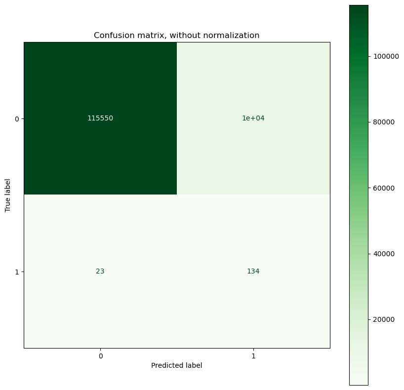

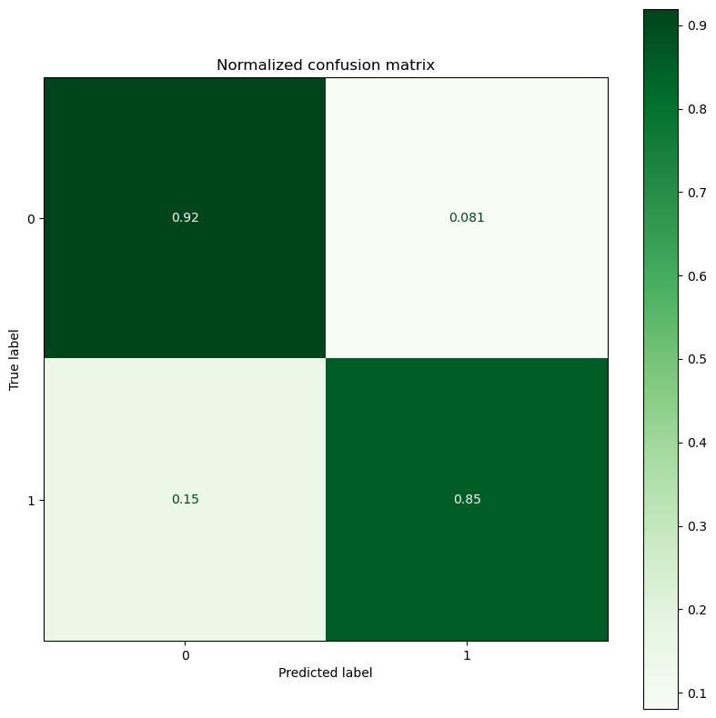

```python
fx.model_analysis(lasso, X_validation, y_validation)
```

## Random Forest

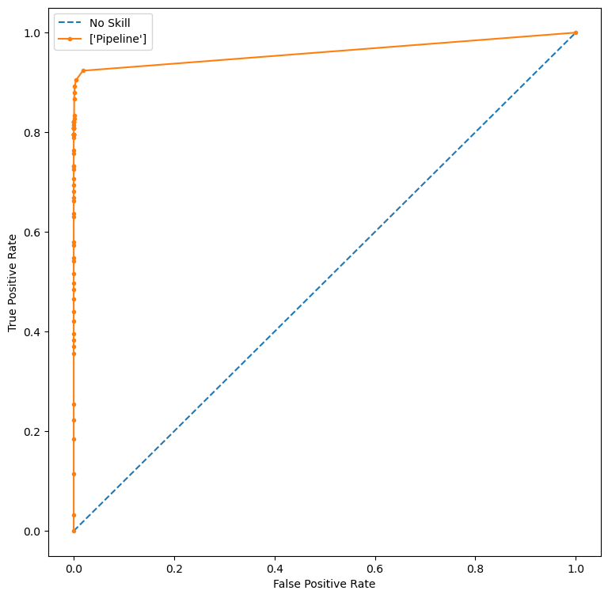

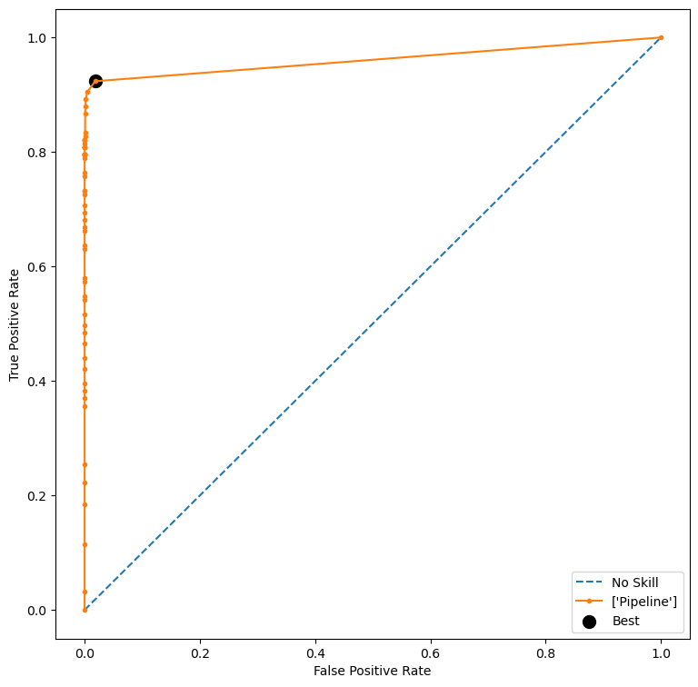

```
ROC-AUC score of the model: 0.9607479869748893
Accuracy of the model: 0.9953905697414746

Classification report:
              precision    recall  f1-score   support

           0       1.00      1.00      1.00    125672
           1       0.20      0.90      0.33       157

    accuracy                           1.00    125829
   macro avg       0.60      0.95      0.66    125829
weighted avg       1.00      1.00      1.00    125829


Confusion matrix:
[[125107    565]
 [    15    142]]

F2 Score:
0.7641057490914109
```

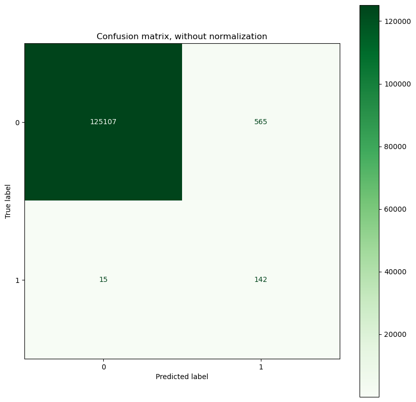

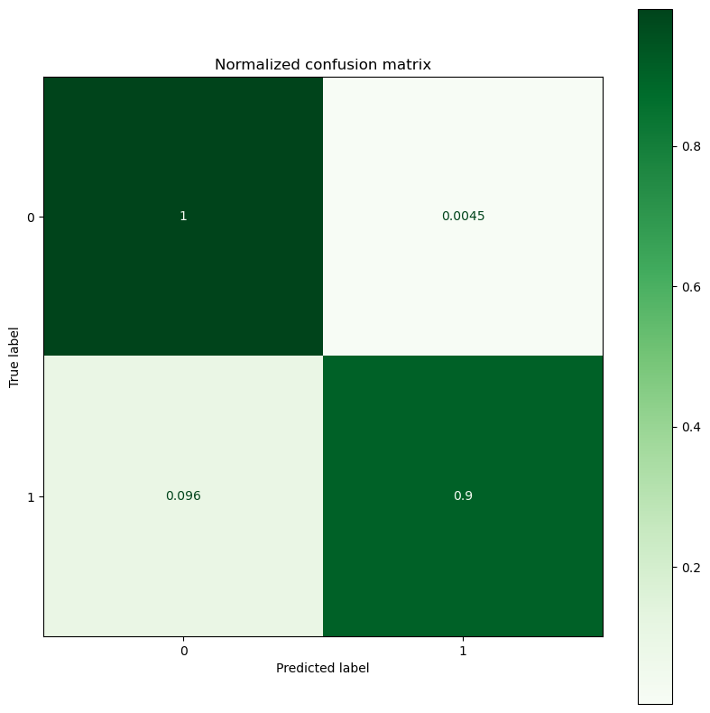

```python
fx.model_analysis(random_forest, X_validation, y_validation)
```

## GLM

```python
# model_analysis(GLM, X_validation, y_validation)
```

## SVM

```python
y_pred_svm = svm.predict(X_validation)
```

```python
with open('../models/pred_svm.pickle', 'wb') as f:
    pickle.dump(y_pred_svm, f)
```

```python
with open('../models/pred_svm.pickle', 'rb') as f:
    y_pred_svm = pickle.load(f)
```

```python
fx.evaluate_model(y_validation, y_pred_svm)
```

```
Accuracy of the model: 0.999038377480549

Classification report:
              precision    recall  f1-score   support

           0       1.00      1.00      1.00    125672
           1       0.97      0.24      0.38       157

    accuracy                           1.00    125829
   macro avg       0.99      0.62      0.69    125829
weighted avg       1.00      1.00      1.00    125829


Confusion matrix:
[[125671      1]
 [   120     37]]

F2 Score:
0.6387902380190904
```

## LightGBM

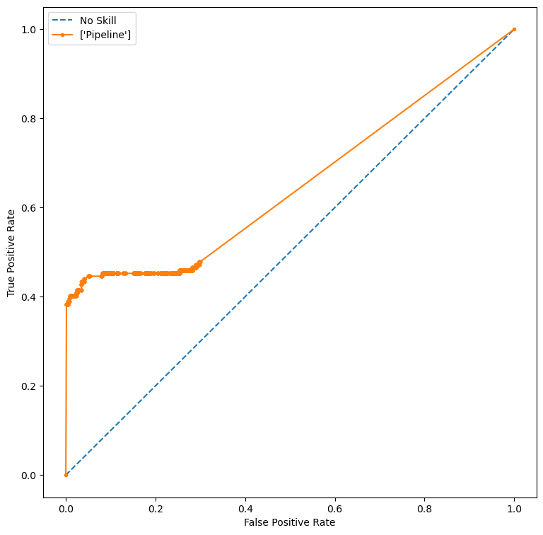

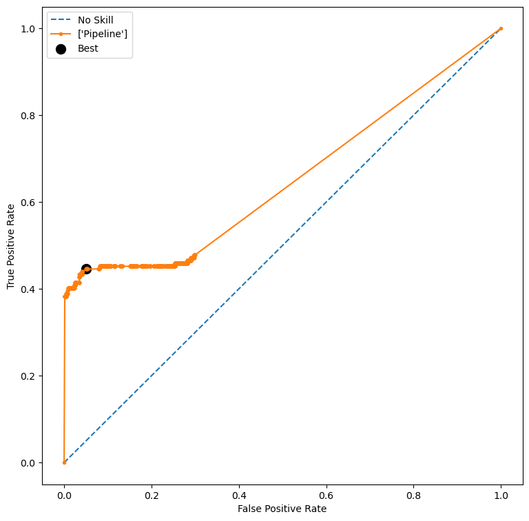

```
ROC-AUC score of the model: 0.6512083016227057
Accuracy of the model: 0.9572197188247542

Classification report:
              precision    recall  f1-score   support

           0       1.00      0.96      0.98    125672
           1       0.01      0.44      0.02       157

    accuracy                           0.96    125829
   macro avg       0.51      0.70      0.50    125829
weighted avg       1.00      0.96      0.98    125829


Confusion matrix:
[[120377   5295]
 [    88     69]]

F2 Score:
0.5117235545271103
```

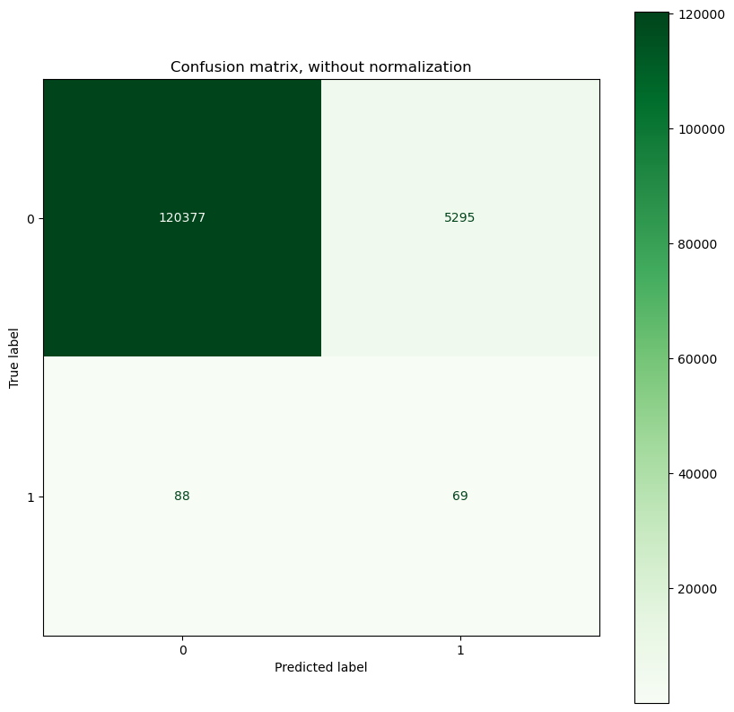

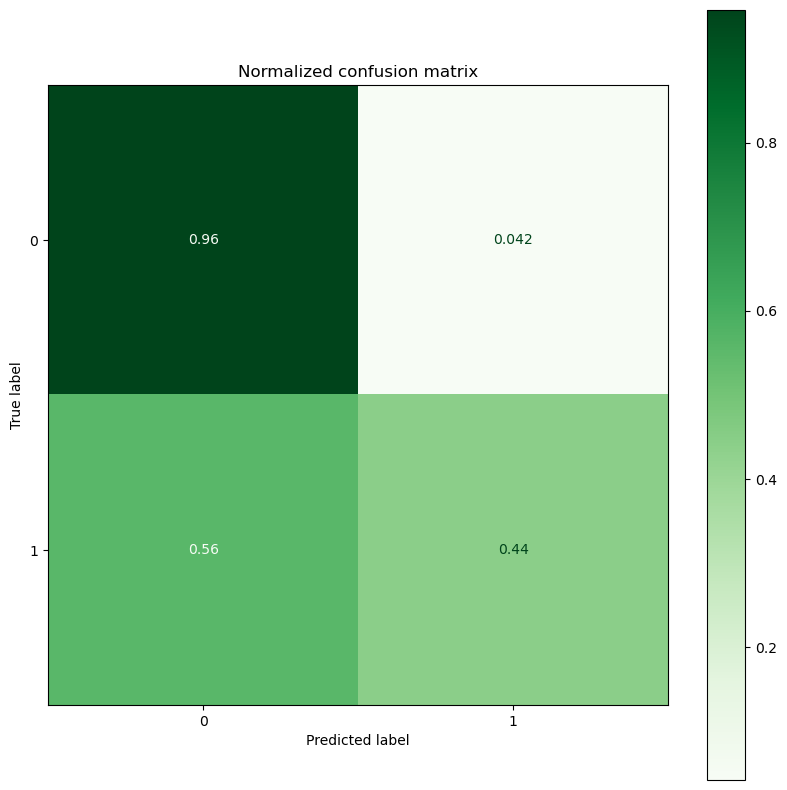

```python
fx.model_analysis(lightgbm, X_validation, y_validation)
```

## XGBoost

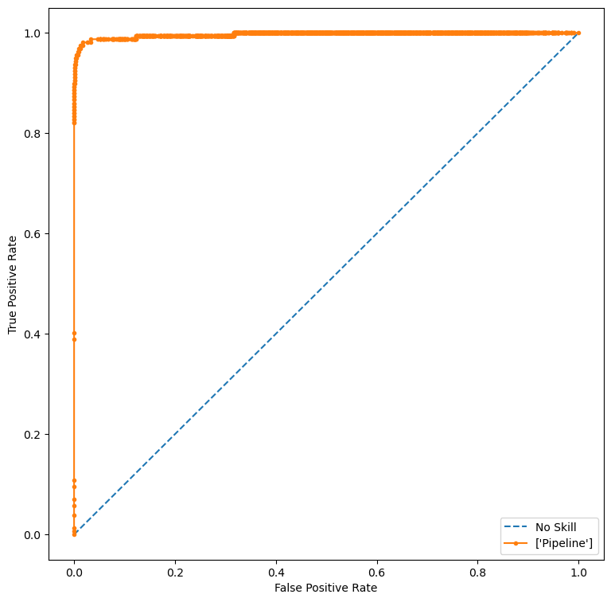

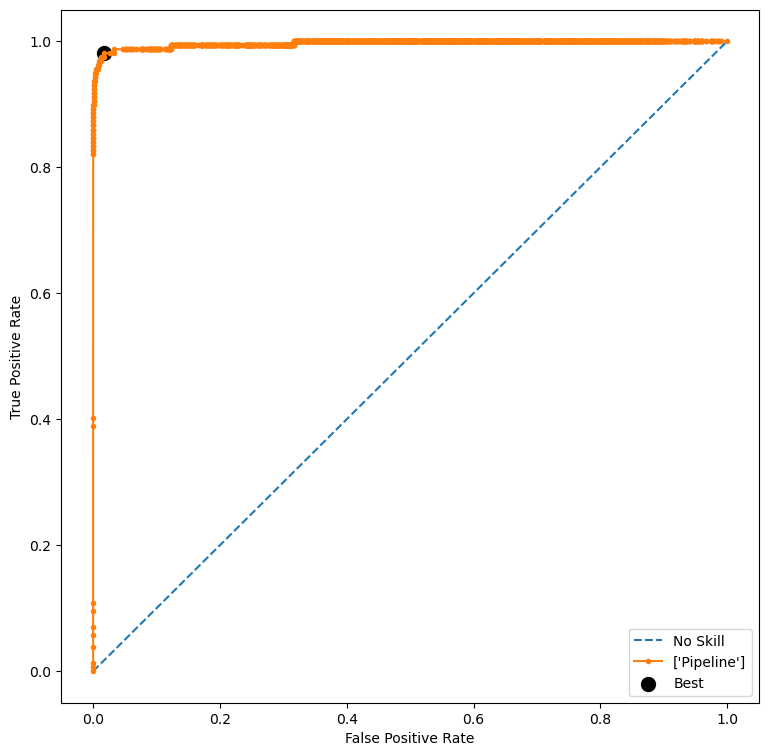

```
ROC-AUC score of the model: 0.9965812834786176
Accuracy of the model: 0.9833583673080133

Classification report:
              precision    recall  f1-score   support

           0       1.00      0.98      0.99    125672
           1       0.07      0.97      0.13       157

    accuracy                           0.98    125829
   macro avg       0.53      0.98      0.56    125829
weighted avg       1.00      0.98      0.99    125829


Confusion matrix:
[[123582   2090]
 [     4    153]]

F2 Score:
0.6265512517215941
```

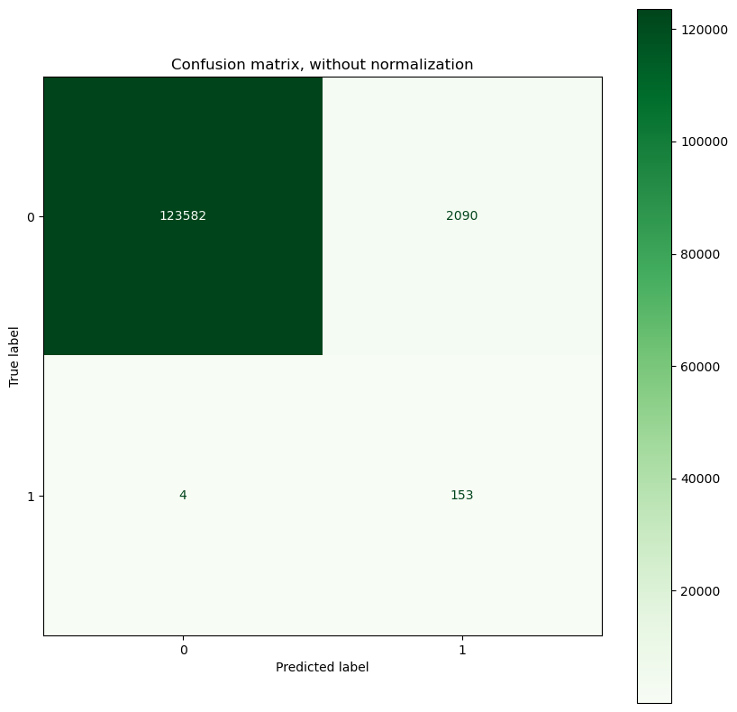

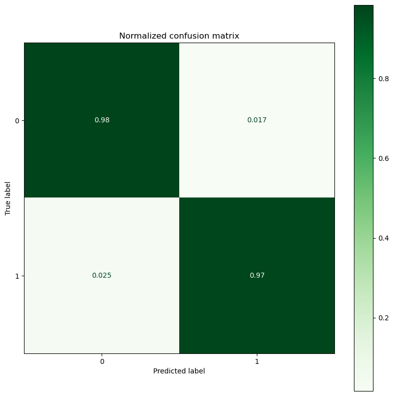

```python
fx.model_analysis(xgboost, X_validation, y_validation)
```

## AdaBoost

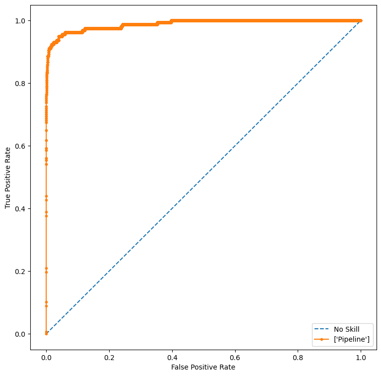

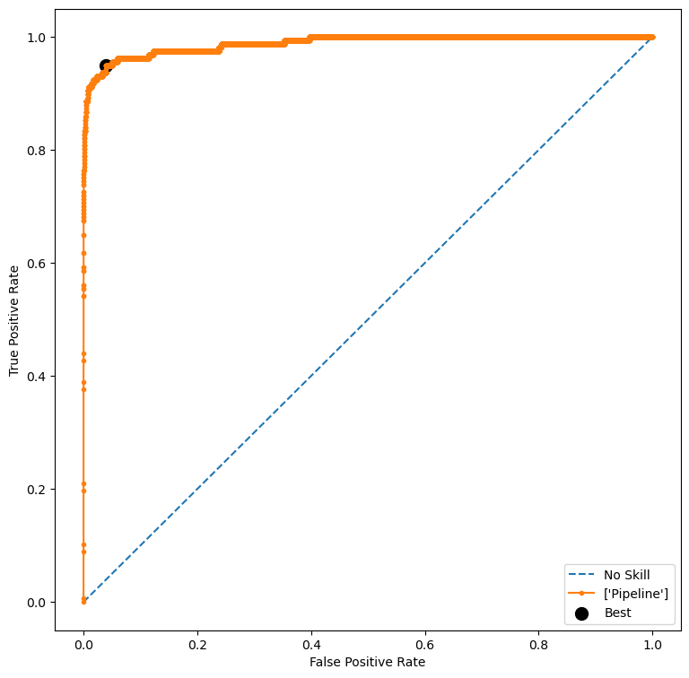

```
ROC-AUC score of the model: 0.988396925897078
Accuracy of the model: 0.9600569026218121

Classification report:
              precision    recall  f1-score   support

           0       1.00      0.96      0.98    125672
           1       0.03      0.94      0.06       157

    accuracy                           0.96    125829
   macro avg       0.51      0.95      0.52    125829
weighted avg       1.00      0.96      0.98    125829


Confusion matrix:
[[120655   5017]
 [     9    148]]

F2 Score:
0.5477661249642923
```

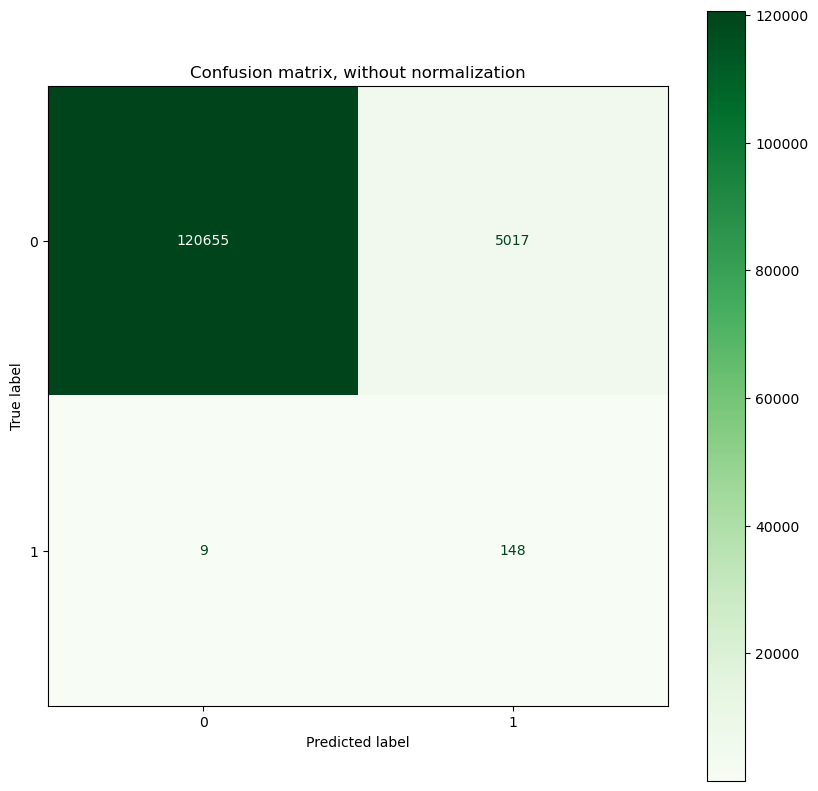

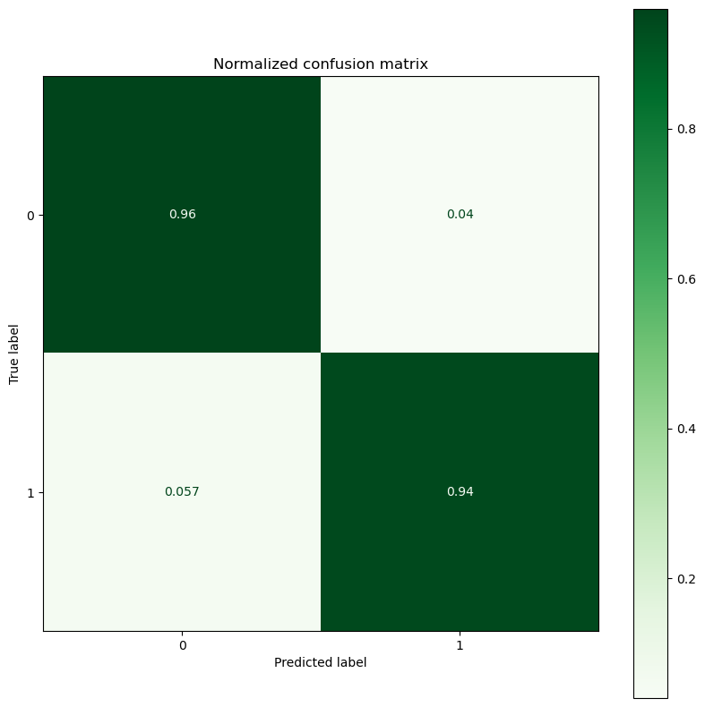

```python
fx.model_analysis(adaboost, X_validation, y_validation)
```

# Summary

```python
# Table with the results obtained

models_data = {'Model': ['Base model', 'Lasso', 'SVM','Random Forest','LightGBM', 'XGBoost', 'AdaBoost'],

                'F1-Score': ['1', '0.92', '1', '1', '0.96', '0.98', '0.96'],

                'F2-Score':['0', '0.499', '0,638', '0.764', '0.511', '0.626', '0.547'],

                'ROC-AUC': ['0.5', '0.958', '-', '0.961', '0.651', '0.996', '0.988'],

                'False positives': ['1', '0.151', '-', '0.096', '0.56', '0.025', '0.057'],

                'True positives': ['1', '0.92', '-', '1', '0.96', '0.98', '0.96']}



metrics_table = pd.DataFrame(models_data, columns=['Model', 'F1-Score', 'F2-Score', 'ROC-AUC', 'False positives',
                                                    'True positives'])
```

```python
metrics_table
```

|  | Model | F1-Score | F2-Score | ROC-AUC | False positives | True positives |
| --- | --- | --- | --- | --- | --- | --- |
| 0 | Base model | 1 | 0 | 0.5 | 1 | 1 |
| 1 | Lasso | 0.92 | 0.499 | 0.958 | 0.151 | 0.92 |
| 2 | SVM | 1 | 0,638 | - | - | - |
| 3 | Random Forest | 1 | 0.764 | 0.961 | 0.096 | 1 |
| 4 | LightGBM | 0.96 | 0.511 | 0.651 | 0.56 | 0.96 |
| 5 | XGBoost | 0.98 | 0.626 | 0.996 | 0.025 | 0.98 |
| 6 | AdaBoost | 0.96 | 0.547 | 0.988 | 0.057 | 0.96 |

The results obtained are very similar for the F1 Score.

For the ROC_AUC all the models with the exception of the base and the lightGBM are above 0.95.

If we take a look at the F2 score, it is apreciated that this metric is the one which diffirienciate most the models. Random Forest obtained the best result with a 0.764, followed by the SVM and the XGBoost with 0.638 and 0.626.

After this results, the Random Forest will be selected for its optimization, as it has obtained the best results overall and its F2 score, which takes into account the false negatives, is the highest with more than 10% difference.